# Global summary

Global summary

Estimates presented here are no longer updated as of 31 March 2022. For more information on the rationale behind this move and some reflections on 2 years of global nowcasting and forecasting, please read our related [blog post](https://epiforecasts.io/posts/2022-03-25-rt-reflections/). See [these instructions](https://github.com/epiforecasts/covid-rt-estimates#reconstructing-historical-estimates-and-forecasts) for reconstructing the full historical time series of reproduction number and other estimates and forecasts.

*Using data available up to the:* 2022-03-30

*Estimates (based on reported cases and deaths) are available for download [here](https://dataverse.harvard.edu/dataverse/covid-rt).*

*See our see [Methods](https://epiforecasts.io/covid/methods) or our [paper](https://wellcomeopenresearch.org/articles/5-112/) for an explanation of how these estimates are derived.*

[interactive chart not shown]

*Figure 1: The results of the latest reproduction number estimates (based on estimated confirmed cases with a date of infection on the 2022-03-30) can be summarised by whether confirmed cases are likely increasing or decreasing. This represents the strength of the evidence that the reproduction number in each region is greater than or less than 1, respectively (see the [methods](https://epiforecasts.io/covid/methods.html) for details). Click on a country (or search) to see national level estimates (and a link to more detailed estimates.*

### Summary of latest reproduction number and confirmed case count estimates by date of infection

[figure not shown]

*Figure 1: Confirmed cases with date of infection on the 2022-03-30 and the time-varying estimate of the effective reproduction number (lightest ribbon = 90% credible interval; darker ribbon = the 50% credible interval, darkest ribbon = 20% credible interval). Regions are ordered by the number of expected daily confirmed cases and shaded based on the expected change in daily confirmed cases. The horizontal dotted line indicates the target value of 1 for the effective reproduction no. required for control and a single case required for elimination. Uncertainty has been curtailed to a maximum of ten times the maximum number of reported cases for plotting purposes.*

### Reproduction numbers over time in the six regions expected to have the most new confirmed cases

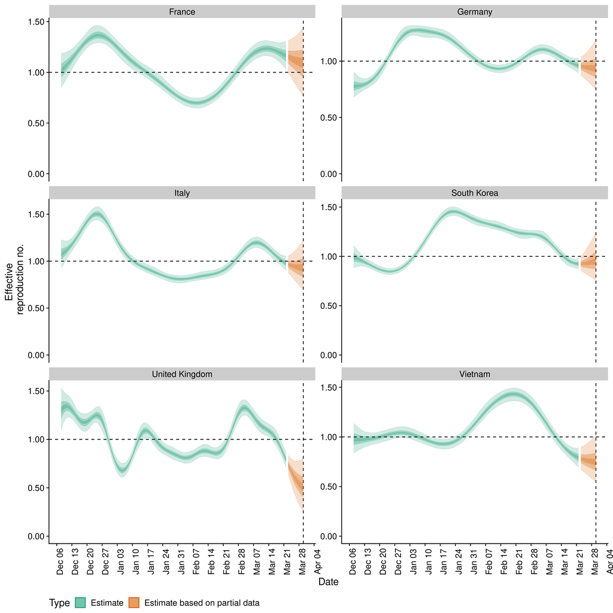

*Figure 2: Time-varying estimate of the effective reproduction number (lightest ribbon = 90% credible interval; darker ribbon = the 50% credible interval, darkest ribbon = 20% credible interval) in the regions expected to have the highest number of new confirmed cases. Estimates from existing data are shown up to the 2022-03-30 from when forecasts are shown. These should be considered indicative only. Estimates based on partial data have been adjusted for right truncation of infections. The vertical dashed line indicates the date of report generation.*

### Confirmed cases and their estimated date of infection in the six regions expected to have the most new confirmed cases

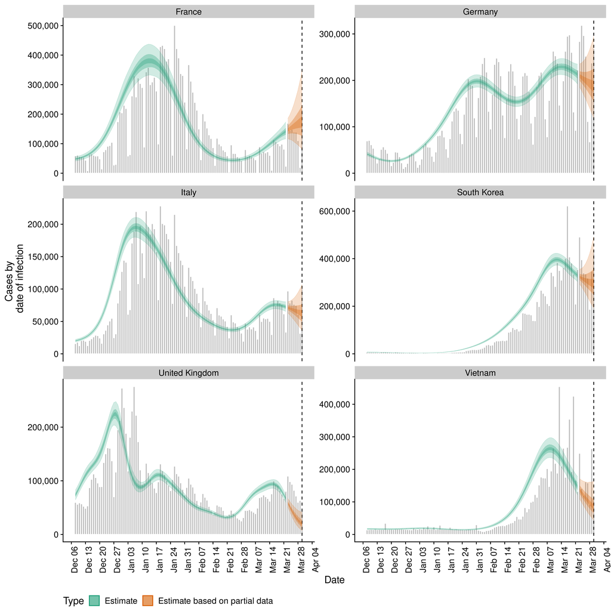

*Figure 3: Confirmed cases by date of report (bars) and their estimated date of infection (lightest ribbon = 90% credible interval; darker ribbon = the 50% credible interval, darkest ribbon = 20% credible interval) in the regions expected to have the highest number of new confirmed cases. Estimates from existing data are shown up to the 2022-03-30 from when forecasts are shown. These should be considered indicative only. Estimates based on partial data have been adjusted for right truncation of infections. The vertical dashed line indicates the date of report generation. Uncertainty has been curtailed to a maximum of ten times the maximum number of reported cases for plotting purposes.*

### Confirmed cases and their estimated date of report in the six regions expected to have the most new confirmed cases

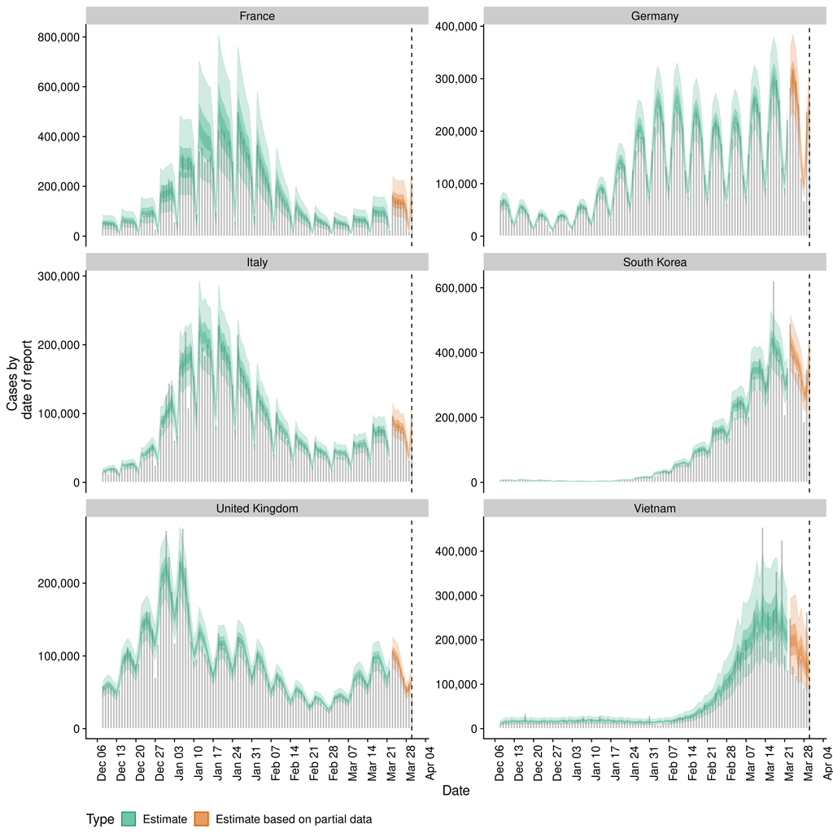

*Figure 4: Confirmed cases by date of report (bars) and their estimated date of report (lightest ribbon = 90% credible interval; darker ribbon = the 50% credible interval, darkest ribbon = 20% credible interval) in the regions expected to have the highest number of new confirmed cases. Estimates from existing data are shown up to the 2022-03-30 from when forecasts are shown. These should be considered indicative only. Estimates based on partial data have been adjusted for right truncation of infections. The vertical dashed line indicates the date of report generation. Uncertainty has been curtailed to a maximum of ten times the maximum number of reported cases for plotting purposes.*

### Latest estimates (as of the 2022-03-30)

*Table 1: Latest estimates (as of the 2022-03-30) of the number of confirmed cases by date of infection, the effective reproduction number, the rate of growth, and the doubling time (when negative this corresponds to the halving time) in each region. The median and 90% credible interval is shown.*

| Country | New confirmed cases by infection date | Expected change in daily cases | Effective reproduction no. | Rate of growth | Doubling/halving time (days) | New confirmed cases by infection date | Effective reproduction no. | Rate of growth | Doubling/halving time (days) |
| --- | --- | --- | --- | --- | --- | --- | --- | --- | --- |
| Afghanistan | 24 (6 -- 98) | Likely decreasing | 0.69 (0.36 -- 1.3) | -0.09 (-0.2 -- 0.085) | -7.7 (8.2 -- -3.5) | 24 | 0.69 | -0.09 | -7.7 |
| Albania | 66 (32 -- 137) | Likely increasing | 1.1 (0.77 -- 1.5) | 0.025 (-0.067 -- 0.13) | 28 (5.2 -- -10) | 66 | 1.1 | 0.025 | 28 |
| Algeria | 8 (1 -- 41) | Stable | 0.92 (0.38 -- 2.1) | -0.022 (-0.19 -- 0.26) | -31 (2.6 -- -3.6) | 8 | 0.92 | -0.022 | -31 |
| American Samoa | 1508 (259 -- 15589) | Likely increasing | 1.6 (0.94 -- 2.6) | 0.15 (-0.017 -- 0.38) | 4.7 (1.8 -- -40) | 1508 | 1.6 | 0.15 | 4.7 |
| Andorra | 13 (2 -- 76) | Likely decreasing | 0.81 (0.45 -- 1.2) | -0.054 (-0.17 -- 0.046) | -13 (15 -- -4.2) | 13 | 0.81 | -0.054 | -13 |
| Angola | 8 (0 -- 104) | Likely decreasing | 0.84 (0.31 -- 2.1) | -0.045 (-0.22 -- 0.27) | -15 (2.6 -- -3.2) | 8 | 0.84 | -0.045 | -15 |
| Anguilla | 8 (1 -- 115) | Likely increasing | 1.4 (0.82 -- 3) | 0.11 (-0.052 -- 0.47) | 6.3 (1.5 -- -13) | 8 | 1.4 | 0.11 | 6.3 |
| Antigua &amp; Barbuda | 3 (0 -- 49) | Likely increasing | 1.3 (0.63 -- 2.7) | 0.072 (-0.11 -- 0.4) | 9.6 (1.7 -- -6.3) | 3 | 1.3 | 0.072 | 9.6 |
| Argentina | 405 (100 -- 1511) | Decreasing | 0.44 (0.21 -- 0.8) | -0.17 (-0.26 -- -0.056) | -4.1 (-12 -- -2.7) | 405 | 0.44 | -0.17 | -4.1 |
| Armenia | 7 (2 -- 24) | Likely decreasing | 0.72 (0.36 -- 1.4) | -0.081 (-0.2 -- 0.098) | -8.6 (7.1 -- -3.5) | 7 | 0.72 | -0.081 | -8.6 |

[output cut: 204 more lines]

Share: